# [R]여러개의 엑셀 sheet에 데이터를 써보자: openxlsx 패키지

by **Youngjun Na**

April 3, 2018

in R

개인적으로 R로만 작업을 한다면 연관된 dataframe들을 list의 형태로 저장해서 사용하는게 편하지만, 주변에 같이 일하는 모든 사람이 R을 능숙하게 다루는 것도 아니고 또 한개의 작업에 연관된 csv 파일을 여러개로 쪼개서 전달해준다거나 하면 불친절한 사람이라는 딱지가 뙇 붙기 십상입니다.

[figure not shown]

(절대 이렇게 생각하면 안된다)

이런 경우, 대용량의 데이터가 아니라면 한개의 엑셀파일에 각각의 데이터를 sheet로 구분해 전달해 주는 것이 가장 효율적인데, 기존의 `xlsx` 패키지를 이용해 `write.xlsx()` 함수를 이용할 경우 여러개의 sheet를 한꺼번에 저장할 수가 없습니다(아마도..).

# openxlsx 패키지

이번 포스팅에서는 `openxlsx` 패키지를 이용하여 **여러개의 데이터프레임을 하나의 엑셀파일에 저장**해 보도록하겠습니다.

```r
library(openxlsx)
```

Workbook을 만들고-sheet를 만들고-쓰고-저장하는 다음 4개의 함수를 기억하시면 됩니다. `createWorkbook()`-`addWorksheet()`-`writeDataTable()`-`saveWorkbook()`

우리가 사랑하는 `iris`와 `mtcars`로 예시 데이터를 만들어 보겠습니다.

```r
a <- iris
b <- mtcars
```

1. 예제 Workbook을 만들고

```r
example <- createWorkbook("example")
example
```

```
## A Workbook object.
##
## Worksheets:
##  No worksheets attached
```

2. Worksheet를 추가해줍니다.

```r
addWorksheet(example, "a")
addWorksheet(example, "b")
example
```

```
## A Workbook object.
##
## Worksheets:
##  Sheet 1: "a"
##
##
##  Sheet 2: "b"
##
##
##
##  Worksheet write order: 1, 2
```

3. 다음과 같이 만들어 놓은 Worksheet에 각 데이터를 넣을 수 있습니다.

```r
writeDataTable(example,"a",a)
writeDataTable(example,"b",b)
```

4. 저장해 줍니다. `write.csv()`와 비슷하게 사용하면 됩니다.

```r
saveWorkbook(example, file="example.xlsx")
```

결과물은 다음과 같습니다.

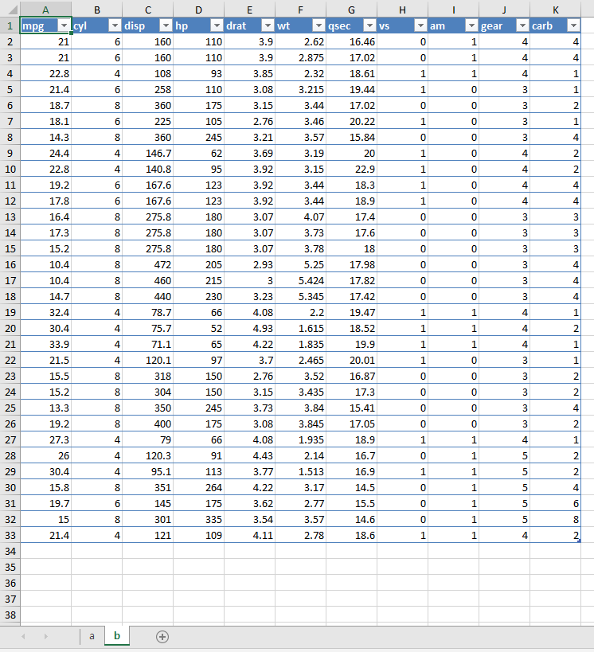

## apply 함수의 응용

다음 [stackoverflow 문서](https://stackoverflow.com/questions/48029854/export-data-frames-in-list-to-xlsx-with-named-sheets?utm_medium=organic&utm_source=google_rich_qa&utm_campaign=google_rich_qa)를 참고하세요.

## 저장 문제 해결

다음과 같은 에러 메시지가 발생하는 경우가 있는데

```
Error: zipping up workbook failed. Please make sure Rtools is installed or a zip application is available to R.
         Try installr::install.rtools() on Windows. If the "Rtools\bin" directory does not appear in Sys.getenv("PATH") please add it to the system PATH
         or set this within the R session with Sys.setenv("R_ZIPCMD" = "path/to/zip.exe")
```

아마도 대부분 다음 코드를 실행함으로 해결이 가능할 것 같습니다.

```r
if(devtools::find_rtools()) Sys.setenv(R_ZIPCMD= file.path(devtools:::get_rtools_path(),"zip"))
```